# assessment

BASIRAT

2024-02-19

#importing libraries to be used for the analysis

```r
libraries <- c("tm", "tidytext", "ggplot2", "wordcloud", "syuzhet", "dplyr", "tibble", "textstem", "textdata", "tidyr", "Matrix", "topicmodels", "stringr", "reshape2", "LDAvis", "jsonlite","e1071")


for (lib in libraries) {
  library(lib, character.only=TRUE)
}
```

# loading dataset and viewing its summary

```r
filepath <- "C:\\Users\\basir\\Desktop\\R\\cw1\\MS4S09_CW_Book_Reviews.csv"

df1 <- as_tibble(read.csv(filepath, stringsAsFactors = FALSE))

print(summary(df1))
```

```
##     Title             Book_Price     Reviewer_id            Rating
##  Length:59296       Min.   :  1.00   Length:59296       Min.   :1.000
##  Class :character   1st Qu.: 10.36   Class :character   1st Qu.:4.000
##  Mode  :character   Median : 14.15   Mode  :character   Median :5.000
##                     Mean   : 20.81                      Mean   :4.231
##                     3rd Qu.: 22.99                      3rd Qu.:5.000
##                     Max.   :995.00                      Max.   :5.000
##       Time           Review_title       Review_text        Found_helpful_ratio
##  Min.   :8.688e+08   Length:59296       Length:59296       Min.   :0.0000
##  1st Qu.:1.087e+09   Class :character   Class :character   1st Qu.:0.0000
##  Median :1.169e+09   Mode  :character   Mode  :character   Median :0.6667
##  Mean   :1.173e+09                                         Mean   :0.5491
##  3rd Qu.:1.279e+09                                         3rd Qu.:1.0000
##  Max.   :1.362e+09                                         Max.   :1.0000
##   Publisher         First_author          Genre
##  Length:59296       Length:59296       Length:59296
##  Class :character   Class :character   Class :character
##  Mode  :character   Mode  :character   Mode  :character
##
##
##
```

#viewing the first and last 5 rows of the dataset

```r
print(head(df1))
```

```
## # A tibble: 6 × 11
##   Title            Book_Price Reviewer_id Rating   Time Review_title Review_text
##   <chr>                 <dbl> <chr>        <int>  <int> <chr>        <chr>
## 1 In Six Days: Wh…      10.2  APD7XINUVG…      4 9.99e8 Solid testi… "Working f…
## 2 Lord Jim              15.6  AITANZIKX8…      5 9.16e8 &quot;You d… "A terrifi…
## 3 White Socks Only       5.16 AYB19RB36G…      4 1.34e9 White Socks… "As I open…
## 4 The Secret of t…      15.0  A1BOLCK0Q5…      5 1.28e9 great!       "Excellent…
## 5 Left to Tell: D…      17.5  A3WKJ88K78…      5 1.36e9 Great Book   "This book…
## 6 Don't Make Me T…      20.9  A1E6I4IPWW…      5 1.20e9 Don't think… "Excellent…
## # ℹ 4 more variables: Found_helpful_ratio <dbl>, Publisher <chr>,
## #   First_author <chr>, Genre <chr>
```

```r
print(tail(df1))
```

```
## # A tibble: 6 × 11
##   Title            Book_Price Reviewer_id Rating   Time Review_title Review_text
##   <chr>                 <dbl> <chr>        <int>  <int> <chr>        <chr>
## 1 Charms And Char…      40.0  AO8P9WP67P…      5 1.17e9 Charms       This is an…
## 2 Anne of the Isl…      45.0  AVTOKS08HO…      5 1.36e9 times revis… I was lost…
## 3 Manga Mania Sho…      13.7  A1JIHS4O8S…      4 1.10e9 Cool and he… I saw this…
## 4 Tales from Kali…      50    A16GAIJJE3…      4 1.31e9 Good storie… This is a …
## 5 Brain Teasers          9.95 A3BBBE8WJZ…      2 1.32e9 Mediocre pu… This puzzl…
## 6 Left to Tell: D…      17.5  A2BYQ1TIQ3…      5 1.36e9 Wonderful b… Was a wond…
## # ℹ 4 more variables: Found_helpful_ratio <dbl>, Publisher <chr>,
## #   First_author <chr>, Genre <chr>
```

```r
df <- df1 #will be used for sentiment analysis
#checking id's with more than one review
head(df %>% group_by(Reviewer_id) %>% count() %>% arrange(desc(n)),10)
```

```
## # A tibble: 10 × 2
## # Groups:   Reviewer_id [10]
##    Reviewer_id        n
##    <chr>          <int>
##  1 A14OJS0VWMOSWO   253
##  2 AFVQZQ8PW0L       98
##  3 A1M8PP7MLHNBQB    44
##  4 AG35NEEFCMQVR     39
##  5 A1NATT3PN24QWY    33
##  6 A1D2C0WDCSHUWZ    29
##  7 A2EDZH51XHFA9B    26
##  8 AHD101501WCN1     25
##  9 A21NVBFIEQWDSG    24
## 10 A2OJW07GQRNJUT    24
```

# Feature selection and sampling

```r
#selecting columns to use for analysis
df <- df %>% select("Title", "Rating", "Review_title",
                    "Review_text","Genre")


# Removing all rows containing null values
df <- na.omit(df)


#creating identifier column to identify individual reviews
1:nrow(df) -> df$Review_id_new

df_tm <- df #for topic modelling
print(df_tm)
```

```
## # A tibble: 59,296 × 6
##    Title                     Rating Review_title Review_text Genre Review_id_new
##    <chr>                      <int> <chr>        <chr>       <chr>         <int>
##  1 In Six Days: Why Fifty S…      4 Solid testi… "Working f… Reli…             1
##  2 Lord Jim                       5 &quot;You d… "A terrifi… Fict…             2
##  3 White Socks Only               4 White Socks… "As I open… Juve…             3
##  4 The Secret of the Lord: …      5 great!       "Excellent… Reli…             4
##  5 Left to Tell: Discoverin…      5 Great Book   "This book… Biog…             5
##  6 Don't Make Me Think: A C…      5 Don't think… "Excellent… Comp…             6
##  7 Eldest (Inheritance, Boo…      5 A good book… "I've neve… Juve…             7
##  8 Search Engine Visibility       5 Finally! An… "Many peop… Comp…             8
##  9 Getting to Know ArcObjec…      5 Excellent f… "This is t… Comp…             9
## 10 Life is tough and then y…      5 It's sad, i… "I love th… Educ…            10
## # ℹ 59,286 more rows
```

#Initial exploration analysis

```r
df %>% group_by(Genre) %>% summarise(count=n()) %>% arrange(desc(count))->genre_counts
head(genre_counts) # Top 5 genres with most count of books
```

```
## # A tibble: 6 × 2
##   Genre                     count
##   <chr>                     <int>
## 1 Fiction                   12663
## 2 Religion                   4266
## 3 Juvenile Fiction           3190
## 4 Biography & Autobiography  3094
## 5 History                    3018
## 6 Business & Economics       2930
```

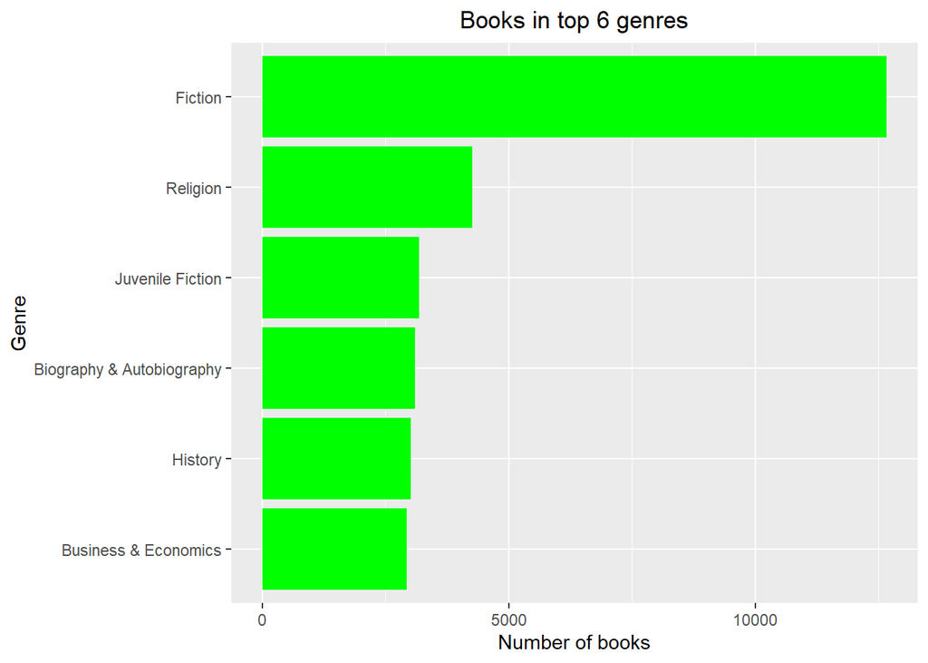

```r
genre_counts$Genre <- reorder(genre_counts$Genre,genre_counts$count)
top_6 <- head(genre_counts,6)

ggplot(top_6)+
  geom_col(aes(y = Genre, x=count),fill='green')+
  labs(x = "Number of books",title = "Books in top 6 genres")+
  theme(plot.title = element_text(hjust = 0.5))
```

```r
summary(genre_counts) # Print summary statistics to see min. max. and average no. of reviews
```

```
##                       Genre        count
##  Authors, English        : 1   Min.   :    1.0
##  Brothers and sisters    : 1   1st Qu.:    8.0
##  Comic books, strips, etc: 1   Median :  225.0
##  English poetry          : 1   Mean   :  697.6
##  Indians of North America: 1   3rd Qu.:  741.0
##  Science fiction         : 1   Max.   :12663.0
##  (Other)                 :79
```

```r
set.seed(1)

# Filtering genres with more than 100 books
greater_than_100 = filter(genre_counts,count >= 100)

#choosing 5 random sample index
sample_index <- sample(length(unique(greater_than_100$Genre)), 5)

#Selecting genres to use for analysis
sampled_genre <- unique(greater_than_100$Genre)[sample_index]
df <- df %>% filter(Genre %in% sampled_genre)
df <- df %>% group_by(Genre) %>% slice_sample(n=100)

#ungrouping to remove groups
df <- ungroup(df)


print(summary(df))
```

```
##     Title               Rating      Review_title       Review_text
##  Length:500         Min.   :1.000   Length:500         Length:500
##  Class :character   1st Qu.:4.000   Class :character   Class :character
##  Mode  :character   Median :5.000   Mode  :character   Mode  :character
##                     Mean   :4.132
##                     3rd Qu.:5.000
##                     Max.   :5.000
##     Genre           Review_id_new
##  Length:500         Min.   :  105
##  Class :character   1st Qu.:15499
##  Mode  :character   Median :30616
##                     Mean   :29860
##                     3rd Qu.:44574
##                     Max.   :59157
```

word tokenization and n-grams tokenization was used to break down the text into smaller units to separate special characters and punctuation from the word.

```r
#Tokenization of the Review text column by words
word_tokenized_data <- df %>%
  unnest_tokens(output = word, input = "Review_text", token = "words", to_lower = TRUE)

#Tokenization of the Review text column into bi-grams
bigram_tokenized_data <- df %>%
  unnest_tokens(output = bigram, input = "Review_text", token = "ngrams", n=2, to_lower = TRUE)
```

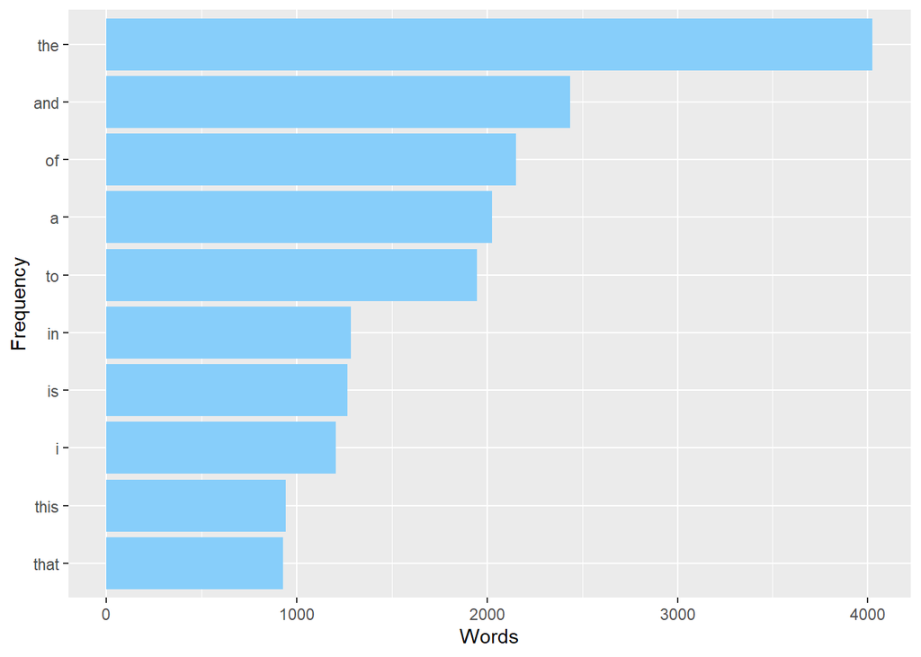

```r
#Plotting the top 10 word sorted tokenized data
word_counts <- word_tokenized_data %>%
  count(word, sort = TRUE)

ggplot(word_counts[1:10, ], aes(y = reorder(word, n), x = n)) +
  geom_col(fill='lightskyblue') +
  labs(x = "Words", y = "Frequency")
```

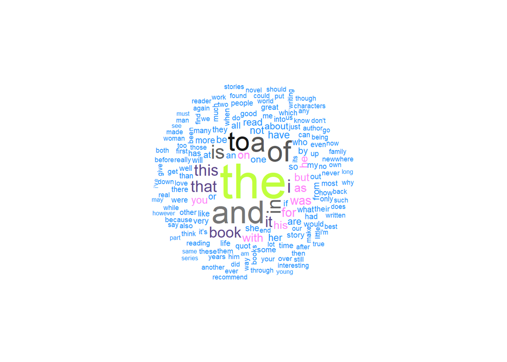

```r
set.seed(1)
wordcloud(words = word_counts$word, freq = word_counts$n, min.freq = 50, random.order=FALSE, random.color=FALSE, colors = sample(colors(), size = 10))
```

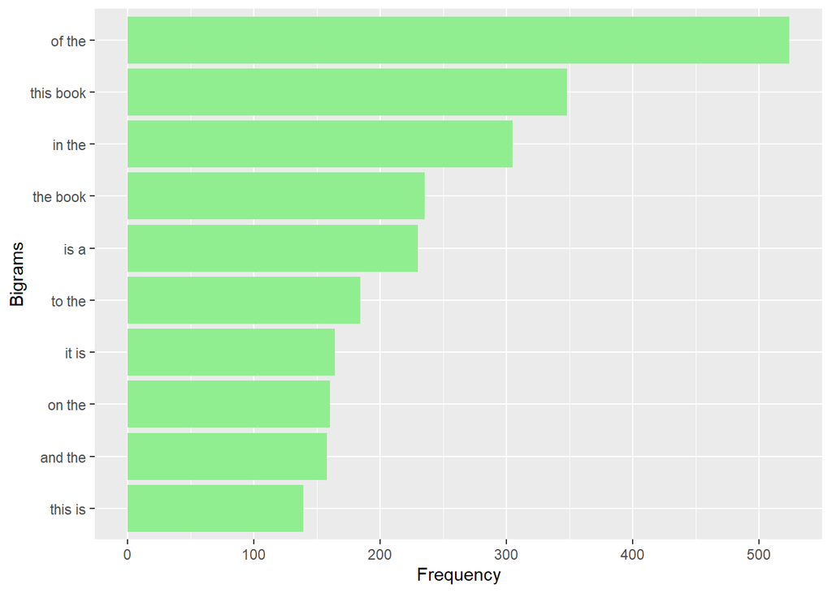

```r
bigram_counts <- bigram_tokenized_data %>%
  count(bigram, sort = TRUE)

ggplot(bigram_counts[1:10, ], aes(x = reorder(bigram, n), y = n)) +
  geom_col(fill = "lightgreen") +
  labs(x = "Bigrams", y = "Frequency") +
  coord_flip()
```

```r
#Removing stop words
clean_tokens <- word_tokenized_data %>%
  anti_join(stop_words, by = "word")


#Removal of special characters and numbers. Also replacing empty strings with NA in order to lemmatize the text.
clean_tokens$word <- gsub("[^a-zA-Z ]", "", clean_tokens$word) %>%
  na_if("") %>%
  lemmatize_words()
clean_tokens <- na.omit(clean_tokens)
```

```r
#Joining the cleaned tokens to the original dataset (df)
untokenized_data <- clean_tokens %>%
  group_by(Review_id_new) %>%
  summarize(clean_review = paste(word, collapse = " ")) %>%
  inner_join(df[,-4], by="Review_id_new")

#Creating n-grams of the clean review column (bi-grams)
clean_bigrams <- untokenized_data %>%
  unnest_tokens(output = bigram, input = "clean_review", token = "ngrams", n=2, to_lower = TRUE)
```

A plot is created for the top 10 cleaned word and bi-grams to confirm the removal of stop words.

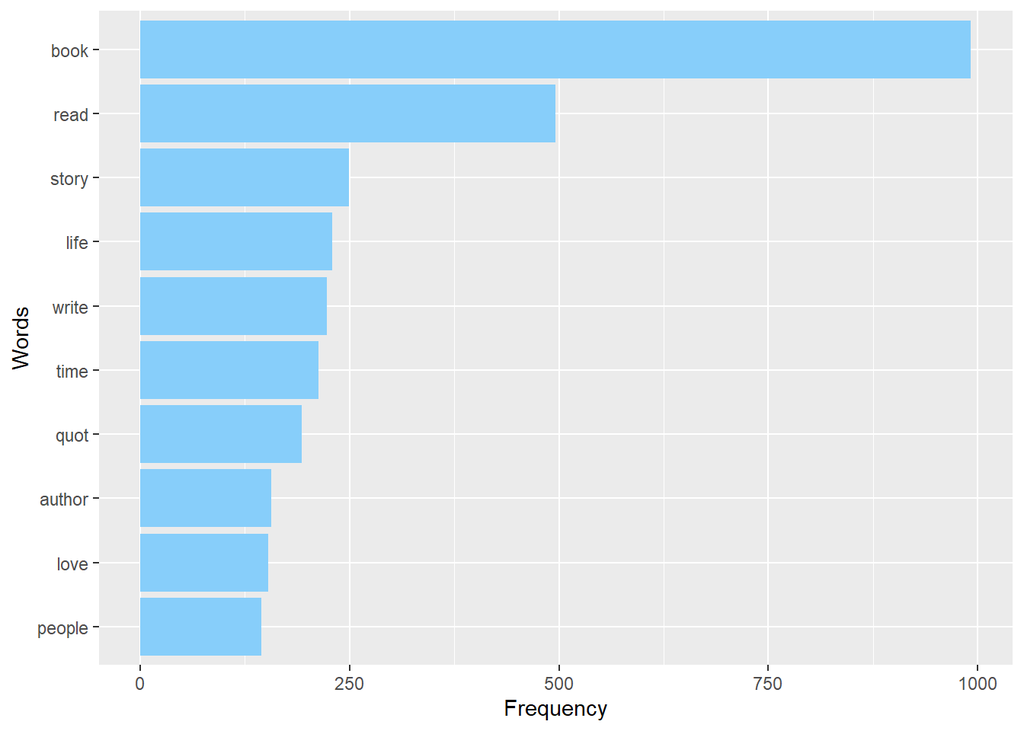

```r
#Creating a count of the cleaned tokens and sorting
word_counts <- clean_tokens %>%
  count(word, sort = TRUE)


#Top 10 words
top_words <- top_n(word_counts,10,n)$word
filtered_word_counts <- filter(word_counts, word %in% top_words)
filtered_word_counts$word <- factor(filtered_word_counts$word, levels = top_words[length(top_words):1])

#Plotting top 10 words
ggplot(filtered_word_counts, aes(x = reorder(word, n), y = n)) +
  geom_col(fill = "lightskyblue") +
  labs(x = "Words", y = "Frequency") +
  coord_flip()
```

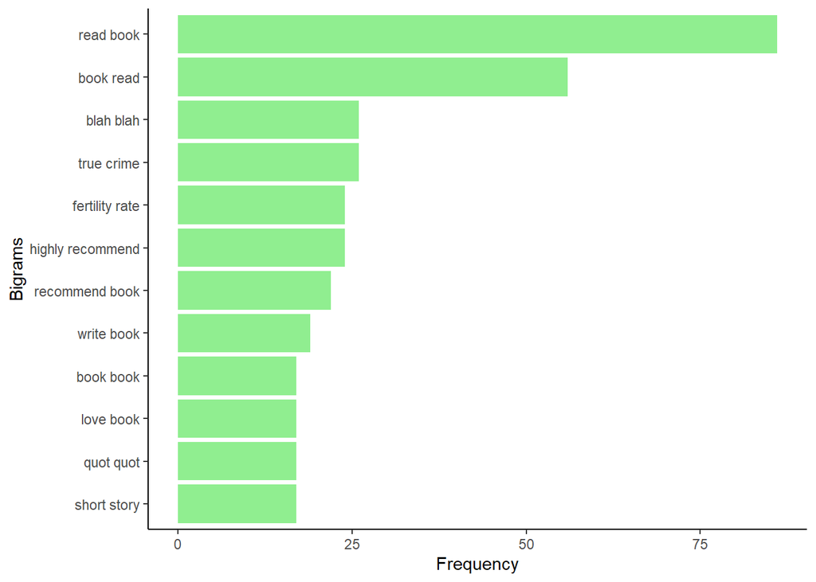

```r
#Creating a count of the bigrams and sorting
bigram_counts <- clean_bigrams %>%
  count(bigram, sort = TRUE)


#Top 10 bi-grams
top_bigrams <- top_n(bigram_counts,10,n)$bigram
filtered_bigram_counts <- filter(bigram_counts, bigram %in% top_bigrams)
filtered_bigram_counts$bigram <- factor(filtered_bigram_counts$bigram, levels = top_bigrams[length(top_bigrams):1])


#Plotting top 10 words
ggplot(filtered_bigram_counts, aes(x = reorder(bigram, n), y = n)) +
  geom_col(fill = "lightgreen") +
  labs(x = "Bigrams", y = "Frequency") +
  coord_flip() +
  theme_classic()
```

The above plot shows the removal of stop words, with words such as books, read and write being top words in the review text of the data.

Further exploration to view the top words used in the five(5) genres chosen for the analysis.

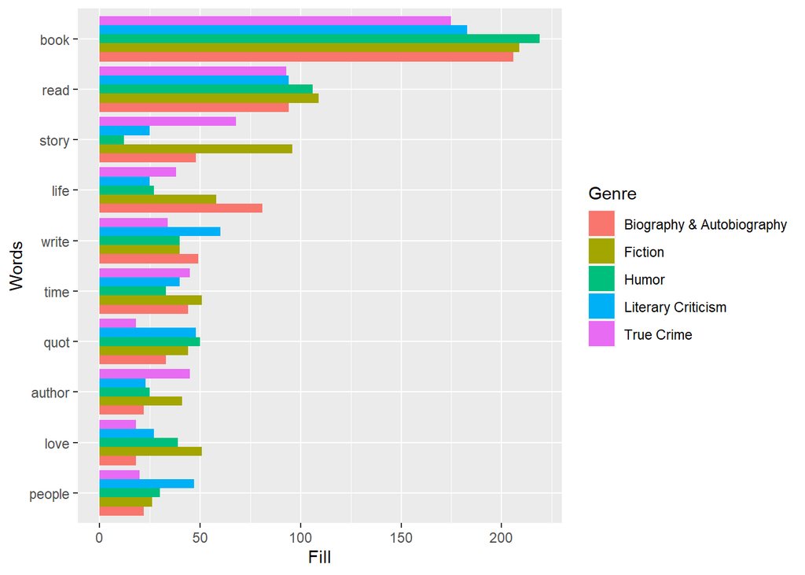

```r
# Grouped Words
top_words <- top_n(word_counts,10,n)$word # Gets a vector of top 10 words

#Grouping the cleaned tokens by genre and filtering by the words in the top 10 words
grouped_count <- group_by(clean_tokens, Genre) %>%
  count(word) %>%
  filter(word %in% top_words)

#Ordering words by frequency
grouped_count$word <- factor(grouped_count$word, levels = top_words[length(top_words):1])

#Plotting the words and filling by genre
ggplot(data = grouped_count, aes(x = word, y = n, fill = Genre)) +
  geom_col(position = "dodge") +
  labs(x = "Words", y = "Fill", fill = "Genre") +
  coord_flip()
```

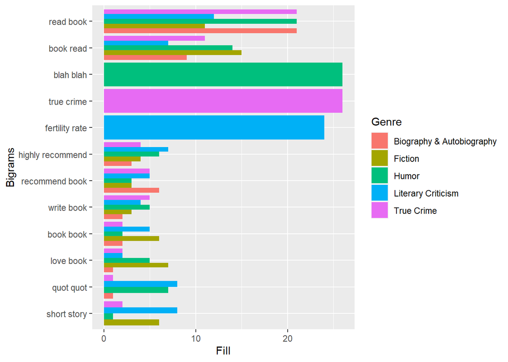

```r
#Top 10 bi-grams per genre
top_bigrams <- top_n(bigram_counts,10,n)$bigram

grouped_count <- group_by(clean_bigrams, Genre) %>%
  count(bigram) %>%
  filter(bigram %in% top_bigrams)

grouped_count$bigram <- factor(grouped_count$bigram, levels = top_bigrams[length(top_bigrams):1])

ggplot(data = grouped_count, aes(x = bigram, y = n, fill = Genre)) +
  geom_col(position = "dodge") +
  labs(x = "Bigrams", y = "Fill", fill = "Genre") +
  coord_flip()
```

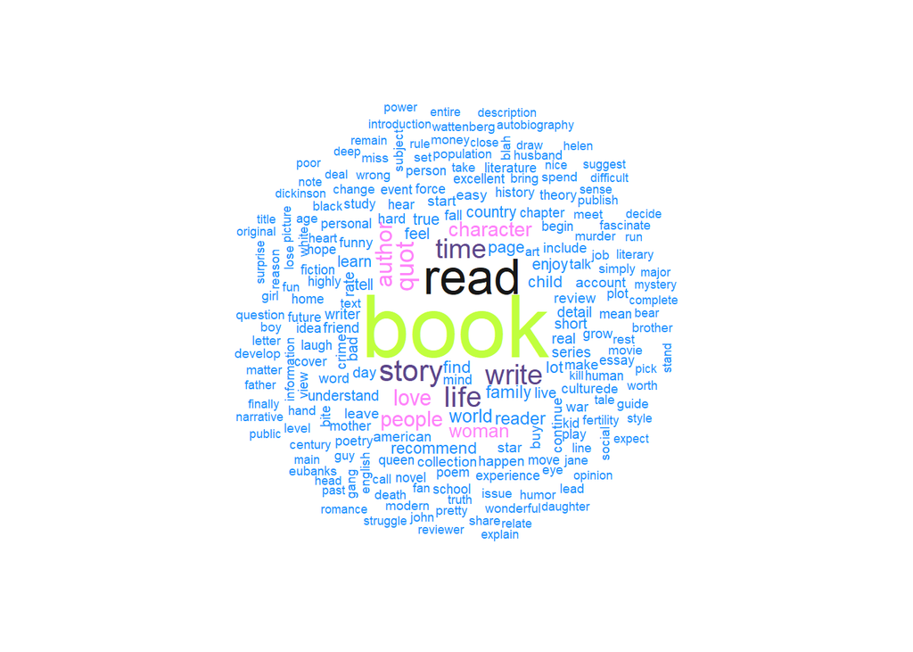

```r
set.seed(1)
wordcloud(words = word_counts$word, freq = word_counts$n, min.freq = 20, random.order=FALSE, random.color=FALSE, colors = sample(colors(), size = 10))
```

Applying bing lexicon

```r
#Forming a new dataset by joining the clean tokens with words present in bing dataset
sentiment_data <- clean_tokens %>%
  inner_join(get_sentiments("bing"), by = "word")


#For each review, a score is calculated
sentiment_score <- sentiment_data %>%
  group_by(Review_id_new) %>%
  summarize(bing_sentiment = sum(sentiment == "positive") - sum(sentiment == "negative"))

#Merging with original df to easily compare scores
df_with_sentiment = df %>%
  inner_join(sentiment_score, by = "Review_id_new")
```

The worst review per the bing scores is shown below:

```r
worst_reviews = df_with_sentiment[order(df_with_sentiment$bing_sentiment)[1],"Review_text"]

for (review in worst_reviews){
  print(review)
}
```

```
## [1] "I would really like to believe what Ben Wattenberg writes in this book \"Fewer\" about the prospects for world population. He thinks that overpopulation is no threat at all. Instead, he says that depopulation is our only cause for concern. But he isn't very persuasive, and seems to repeatedl…
```

The review with the best bing score is shown below:

```r
best_reviews = df_with_sentiment[order(df_with_sentiment$bing_sentiment, decreasing = TRUE)[1],"Review_text"]

for (review in best_reviews){
  print(review)
}
```

```
## [1] "It is an honor to the be first to review this book on Amazon. This book is not exactly genius, but then again maybe it is. I can't tell what genius is anymore, but this is a kind of genius. Forget the review of the book that appears above from Publisher's Weekly (ok, not completely--they are…
```

The highest review text using the bing score 20, with its genre being ‘Humor’ has a 5 star rating.

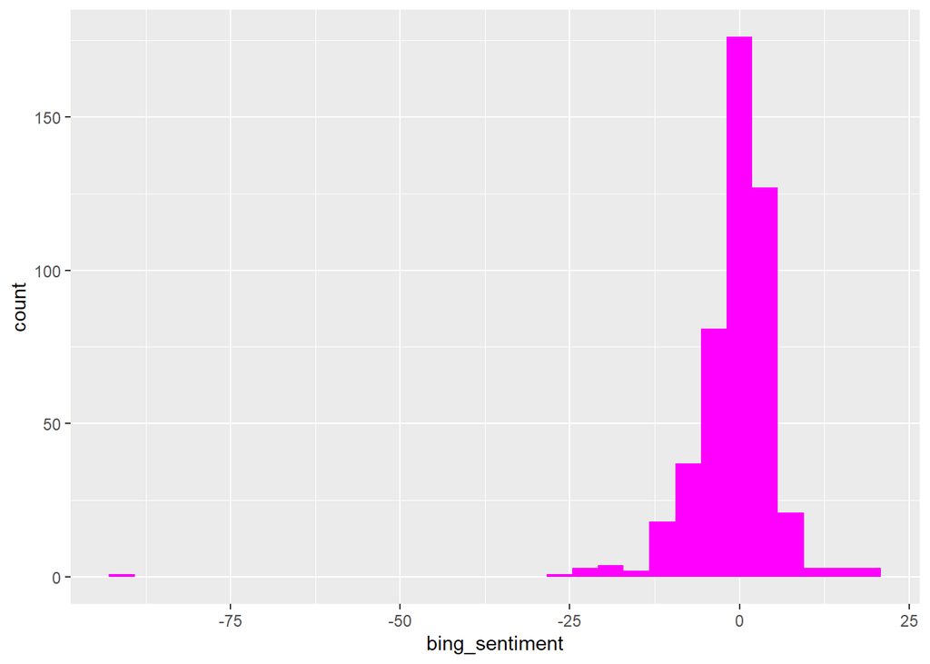

```r
# Histogram of sentiment scores
ggplot(df_with_sentiment, aes(x = bing_sentiment)) +
  geom_histogram(fill='magenta')
```

The bing scores shows majority of the scores between 25 to -25.

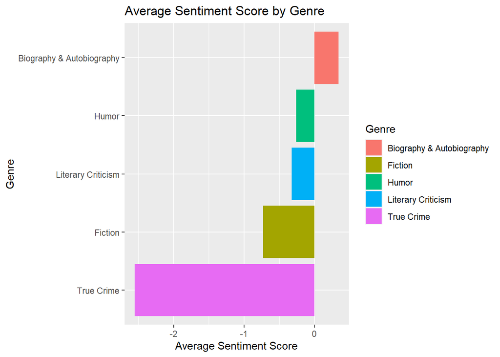

```r
# Average sentiment scores by genre
book_sentiment <- df_with_sentiment %>%
  group_by(Genre) %>%
  summarize(avg_sentiment_score = mean(bing_sentiment))

ggplot(book_sentiment)+
  geom_bar(aes(x = reorder(Genre, avg_sentiment_score),
               y = avg_sentiment_score, fill = Genre),stat = "identity") +
  coord_flip() +
  labs(title = "Average Sentiment Score by Genre", x = "Genre",
       y = "Average Sentiment Score")
```

The positive average scores shows Biography and Autobiography with positive sentiments.

The distribution of scores according to genres:

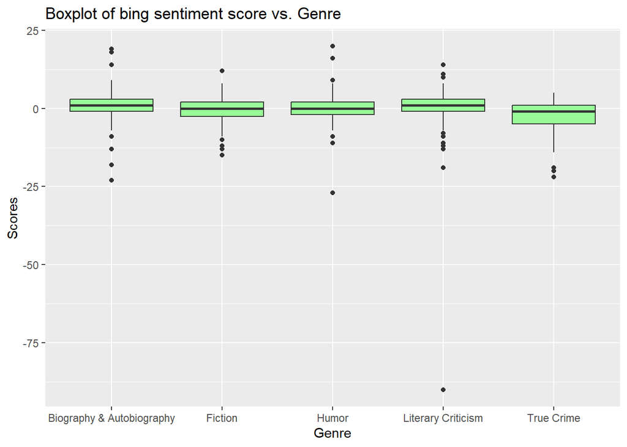

```r
ggplot(df_with_sentiment) +
  geom_boxplot(aes(y = bing_sentiment, x=Genre,group=Genre),fill='palegreen') +
  labs(title = "Boxplot of bing sentiment score vs. Genre",
       y = "Scores",
       x = "Genre")
```

Applying the AFINN lexicon. Words in AFINN lexicon are associated with a sentiment score each, ranging from -5 to +5 which indicates its polarity or emotional intensity..

```r
#Forming a new dataset by joining the clean tokens with words present in AFINN lexicon
sentiment_data <- clean_tokens %>%
  inner_join(get_sentiments("afinn"), by = "word")

##For each review, a score is calculated
sentiment_score <- sentiment_data %>%
  group_by(Review_id_new) %>%
  summarize(afinn_sentiment = sum(value))

#Merging with df
df_with_sentiment = df_with_sentiment %>%
  inner_join(sentiment_score, by = "Review_id_new")
```

Worst afinn scores is shown below:

```r
worst_reviews = df_with_sentiment[order(df_with_sentiment$afinn_sentiment)[1],"Review_text"]

for (review in worst_reviews){
  print(review)
}
```

```
## [1] "William Queen spent 28 months undercover with the Mongols motorcycle group - feared more than Hells Angels. His bravery and \"street intelligence\" are incredible. Drugs, illegal weapons, gang-rape, witness intimidation, brutal beatings, and motorcycle theft were the gang's most common unlaw…
```

```r
best_reviews = df_with_sentiment[order(df_with_sentiment$afinn_sentiment, decreasing = TRUE)[1],"Review_text"]

for (review in best_reviews){
  print(review)
}
```

```
## [1] "I have been waiting a long time to read one of Nora's books especially since I love \"When Sally Met Harry\" and \"Sleepless in Seattle\" and her other movies. When I found out that she wrote books, I was in heaven! But I never seem to find them at the bookstore or any place. So I requested …
```

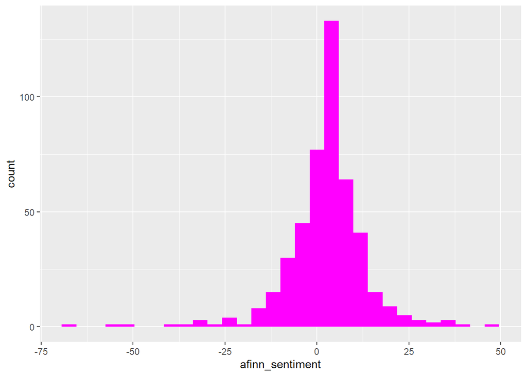

```r
# Histogram of sentiment scores
ggplot(df_with_sentiment, aes(x = afinn_sentiment)) +
  geom_histogram(fill='magenta')
```

Most of the scores are between -25 to 25 except a few exceeding 25 and a few lesser than 25.

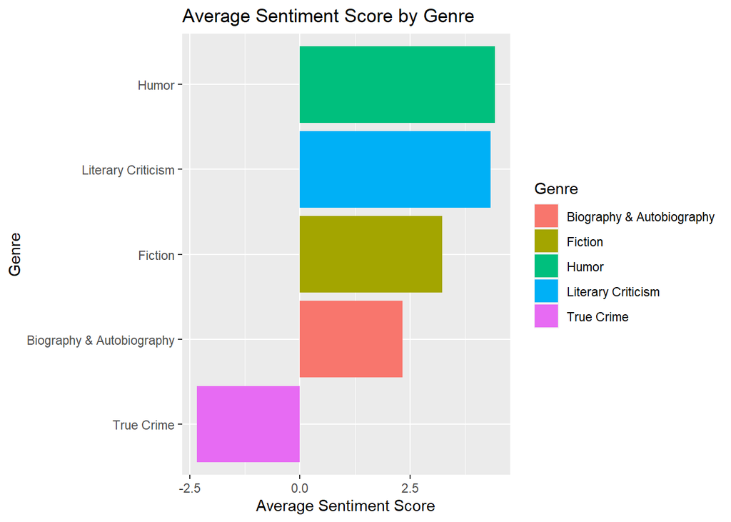

```r
# Average Sentiment by Genre
genre_sentiment <- df_with_sentiment %>%
  group_by(Genre) %>%
  summarize(avg_afinn_sentiment = mean(afinn_sentiment))

ggplot(genre_sentiment, aes(x = reorder(Genre, avg_afinn_sentiment),
                             y = avg_afinn_sentiment, fill = Genre)) +
  geom_bar(stat = "identity") +
  coord_flip() +
  labs(title = "Average Sentiment Score by Genre", x = "Genre", y = "Average Sentiment Score")
```

True Crime was the only genre that recorded a negative average of sentiment scores. Humor had an average that was slightly higher than Literary criticism.

Showing the distribution of scores according to genres

[figure not shown]

```r
ggplot(df_with_sentiment) +
  geom_boxplot(aes(y = afinn_sentiment, x=Genre,group=Genre),fill='palegreen') +
  labs(title = "Boxplot of bing sentiment score vs. Genre",
       y = "Scores",
       x = "Genre")
```

The relationship between BING scores and AFINN scores is:

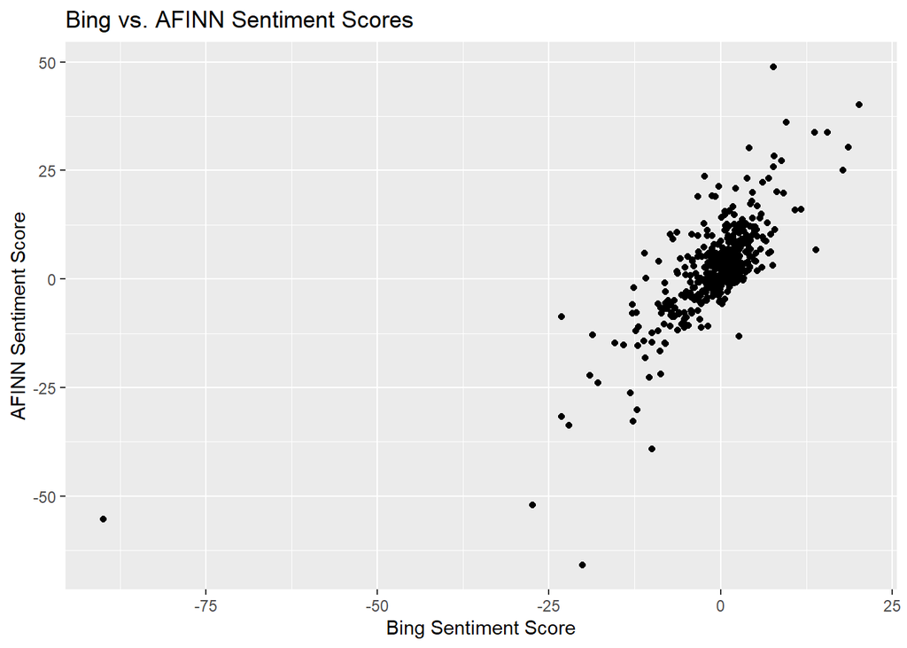

```r
ggplot(df_with_sentiment) +
  geom_jitter(aes(x = bing_sentiment,y = afinn_sentiment)) +
  labs(title = "Bing vs. AFINN Sentiment Scores",
       x = "Bing Sentiment Score",
       y = "AFINN Sentiment Score")
```

Eight basic emotions i.e disgust, joy, sadness, surprise, trust, anticipation, fear and anger are associated with the NRC lexicon and also two sentiments (positive or negative)

```r
#Forming a new dataset by joining the clean tokens with the NRC lexicon
emotion_data <- clean_tokens %>%
  inner_join(get_sentiments("nrc"), by = "word")
#Sentiment scores for each review
emotion_count <- emotion_data %>%
  group_by(Review_id_new) %>%
  count(sentiment)

#Pivots data so that there is a column associated with each emotion
wide_emotion_data <- emotion_count %>%
  pivot_wider(names_from = sentiment, values_from = n, values_fill = list(n = 0))

#Merging with df
df_with_sentiment = df_with_sentiment %>%
  inner_join(wide_emotion_data, by = "Review_id_new")
```

```r
#Viewing the highest score in each of the emotions below

emotions <- c("joy", "positive", "trust", "anticipation", "surprise", "sadness", "negative", "anger", "disgust", "fear")

for (emotion in emotions){
  print(paste("Review with highest score in", emotion))
  cat("\n")
  cat("\n")
  review <- pull(df_with_sentiment[order(df_with_sentiment[[emotion]], decreasing = TRUE)[1],"Review_text"],"Review_text")
  print(review)
  cat("\n")}
```

```
## [1] "Review with highest score in joy"
##
##
## [1] "I would really like to believe what Ben Wattenberg writes in this book \"Fewer\" about the prospects for world population. He thinks that overpopulation is no threat at all. Instead, he says that depopulation is our only cause for concern. But he isn't very persuasive, and seems to repeatedl…
##
## [1] "Review with highest score in positive"
##
##
## [1] "I would really like to believe what Ben Wattenberg writes in this book \"Fewer\" about the prospects for world population. He thinks that overpopulation is no threat at all. Instead, he says that depopulation is our only cause for concern. But he isn't very persuasive, and seems to repeatedl…
##
## [1] "Review with highest score in trust"
##
##
## [1] "I would really like to believe what Ben Wattenberg writes in this book \"Fewer\" about the prospects for world population. He thinks that overpopulation is no threat at all. Instead, he says that depopulation is our only cause for concern. But he isn't very persuasive, and seems to repeatedl…
##
## [1] "Review with highest score in anticipation"
##
##
## [1] "I would really like to believe what Ben Wattenberg writes in this book \"Fewer\" about the prospects for world population. He thinks that overpopulation is no threat at all. Instead, he says that depopulation is our only cause for concern. But he isn't very persuasive, and seems to repeatedl…
##
## [1] "Review with highest score in surprise"
##
##
## [1] "I would really like to believe what Ben Wattenberg writes in this book \"Fewer\" about the prospects for world population. He thinks that overpopulation is no threat at all. Instead, he says that depopulation is our only cause for concern. But he isn't very persuasive, and seems to repeatedl…
##
## [1] "Review with highest score in sadness"
##
##
## [1] "I would really like to believe what Ben Wattenberg writes in this book \"Fewer\" about the prospects for world population. He thinks that overpopulation is no threat at all. Instead, he says that depopulation is our only cause for concern. But he isn't very persuasive, and seems to repeatedl…
##
## [1] "Review with highest score in negative"
##
##
## [1] "I would really like to believe what Ben Wattenberg writes in this book \"Fewer\" about the prospects for world population. He thinks that overpopulation is no threat at all. Instead, he says that depopulation is our only cause for concern. But he isn't very persuasive, and seems to repeatedl…
##
## [1] "Review with highest score in anger"
##
##
## [1] "Let's face it - one of the great pleasures in life is reading a good book. No one else around, no children/spouse/co-workers/pets bothering you - just peace, quiet and a good book, something to take you away from life's everyday trials and tribulations. The \"alt-history\" genre in particula…
##
## [1] "Review with highest score in disgust"
##
##
## [1] "I would really like to believe what Ben Wattenberg writes in this book \"Fewer\" about the prospects for world population. He thinks that overpopulation is no threat at all. Instead, he says that depopulation is our only cause for concern. But he isn't very persuasive, and seems to repeatedl…
##
## [1] "Review with highest score in fear"
##
##
## [1] "Let's face it - one of the great pleasures in life is reading a good book. No one else around, no children/spouse/co-workers/pets bothering you - just peace, quiet and a good book, something to take you away from life's everyday trials and tribulations. The \"alt-history\" genre in particula…
```

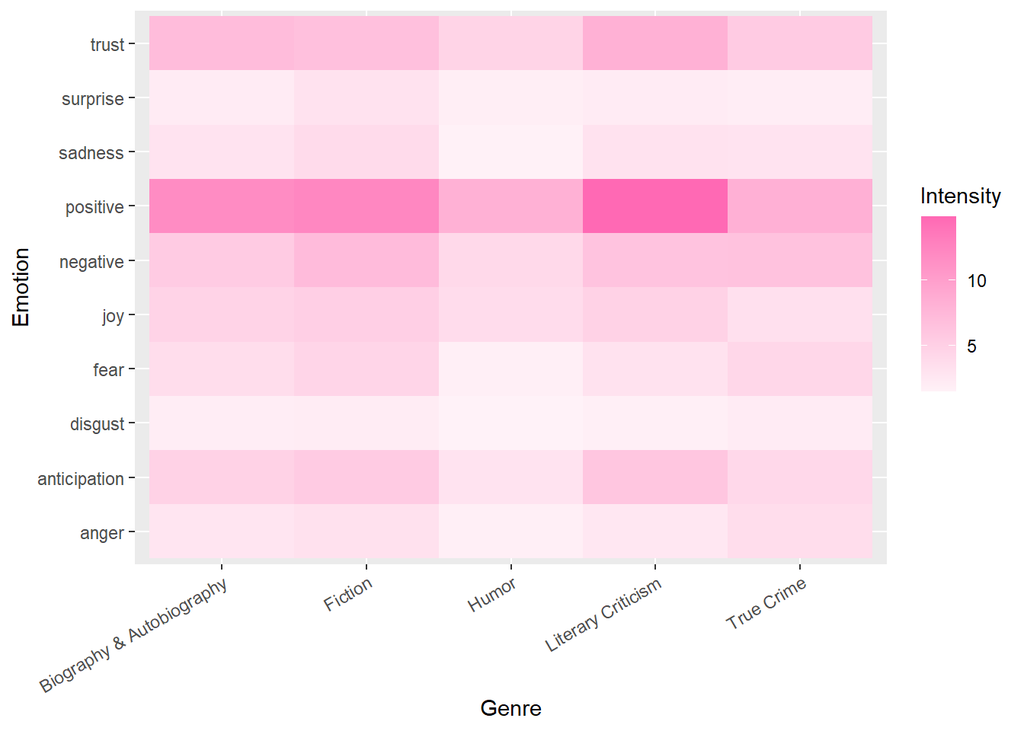

```r
#Creating a heatmap to show

long_df <- df_with_sentiment %>%
  pivot_longer(cols = c("joy", "positive", "trust", "anticipation", "surprise", "sadness", "negative", "anger", "disgust", "fear"),
               names_to = "Emotion",
               values_to = "Intensity")

emotion_scores <- long_df %>%
  group_by(Genre, Emotion) %>%
  summarize(avg_intensity = mean(Intensity))
ggplot(emotion_scores, aes(x = Genre, y = Emotion, fill = avg_intensity)) +
  geom_tile() +
  scale_fill_gradient2(low = "white", high = "hotpink") +  # Adjust colors
  labs(x = "Genre", y = "Emotion", fill = "Intensity") +
  theme(axis.text.x = element_text(angle = 30, hjust=1))
```

Disgust, joy, sadness, surprise, trust, anticipation, fear and anger are associated with the NRC lexicon and two sentiments (positive or negative)

#PART 2 #Topic modelling Topic modelling are used to understand the hidden patterns in the segmentation of customers by reviewing text feature to determine clusters.

An initial data exploration analysis is performed below:

```r
df_tm %>% group_by(Genre) %>% summarise(count=n()) %>% arrange(desc(count))->genre_counts
head(genre_counts) # Print top 6 most reviewed genres
```

```
## # A tibble: 6 × 2
##   Genre                     count
##   <chr>                     <int>
## 1 Fiction                   12663
## 2 Religion                   4266
## 3 Juvenile Fiction           3190
## 4 Biography & Autobiography  3094
## 5 History                    3018
## 6 Business & Economics       2930
```

```r
summary(genre_counts) # Print summary statistics to see min. max. and average no. of reviews
```

```
##     Genre               count
##  Length:85          Min.   :    1.0
##  Class :character   1st Qu.:    8.0
##  Mode  :character   Median :  225.0
##                     Mean   :  697.6
##                     3rd Qu.:  741.0
##                     Max.   :12663.0
```

Data selection is an important part of topic modelling. selecting the right data key in preventing computationally expensive model.

The “review_text” feature is a source of finding topics. The text count selected from the analysis ranges from 100 to 500 characters.

Ten genres was used for the analysis and 5,144 observations selected

```r
df_tm <- df_tm %>%
  filter(str_count(Review_text) >= 100 & str_count(Review_text) <= 500)

set.seed(034)

# selecting genres that have more than 100 reviews.
greater_than_100 = filter(genre_counts,count >= 100)


#Ten indexes to aid in selecting 10 genres
sample_index <- sample(length(unique(greater_than_100$Genre)), 10)
sampled_genre <- unique(greater_than_100$Genre)[sample_index]
df_tm <- df_tm %>% filter(Genre %in% sampled_genre)

#df_tm <- df_tm %>% group_by(Genre) %>% slice_sample(n=100)

#df_tm <- ungroup(df_tm)

print(sampled_genre)
```

```
##  [1] "Young Adult Fiction"    "Reference"              "Cooking"
##  [4] "Health & Fitness"       "Family & Relationships" "Crafts & Hobbies"
##  [7] "Medical"                "Literary Collections"   "Body, Mind & Spirit"
## [10] "Psychology"
```

```r
print(df_tm)
```

```
## # A tibble: 5,144 × 6
##    Title                     Rating Review_title Review_text Genre Review_id_new
##    <chr>                      <int> <chr>        <chr>       <chr>         <int>
##  1 Strips 'n Curves: A New …      5 Fabric art … "I watched… Craf…            34
##  2 Aging Well: Surprising G…      5 For all age… "What migh… Psyc…            45
##  3 The Coaches' Chalkboard:…      5 Very Inspir… "This was … Refe…            50
##  4 Meditations from the Mat…      5 Daily Guida… "Definitel… Heal…            53
##  5 The Psychic Pathway: A W…      5 As close as… "Having ha… Body…            62
##  6 The Spirit Book: The Enc…      5 Very thorou… "lots of i… Body…            77
##  7 The Meditation Bible: Th…      5 Great!       "I really … Body…           104
##  8 The Basic Principles of …      4 Only Got It… "This is p… Psyc…           124
##  9 Tarot of the Spirit            5 If I can re… "My Favori… Body…           125
## 10 Drumstick Spinology (Boo…      1 Terrible pu… "I regret … Craf…           135
## # ℹ 5,134 more rows
```

```r
# Convert review text to corpus
corpus <- VCorpus(VectorSource(df_tm$Review_text))

# Creating additional stopwords
myStopwords <- c(stopwords("en"),'will','want','just','well',"dont","even","thing","cant","still","really","every","take","tell","must",'make')
corpus <- tm_map(corpus, content_transformer(tolower)) %>%
  tm_map(content_transformer(function(x) gsub("[^a-zA-Z ]", "", x))) %>% tm_map(removeWords, myStopwords) %>%
  tm_map(stemDocument)

#Term document matrix
tdm <- TermDocumentMatrix(corpus, control = list(wordLengths = c(4, 15)))

tdm_matrix <- as.matrix(tdm)
```

Displaying top 10 words/terms with their frequencies.

```r
term_frequencies <- rowSums(tdm_matrix)

# Create a data frame for plotting
term_frequency_df <- data.frame(term = names(term_frequencies), frequency = term_frequencies)

#Top 10 terms in descending order
top_terms <- term_frequency_df %>%
  arrange(desc(frequency)) %>%
  head(10)

print(top_terms)
```

```
##                term frequency
## book           book      6967
## read           read      2026
## great         great      1332
## help           help      1023
## love           love       931
## good           good       902
## recip         recip       848
## recommend recommend       818
## like           like       786
## inform       inform       743
```

A histogram displaying term freqencies after the removal of stopwords.

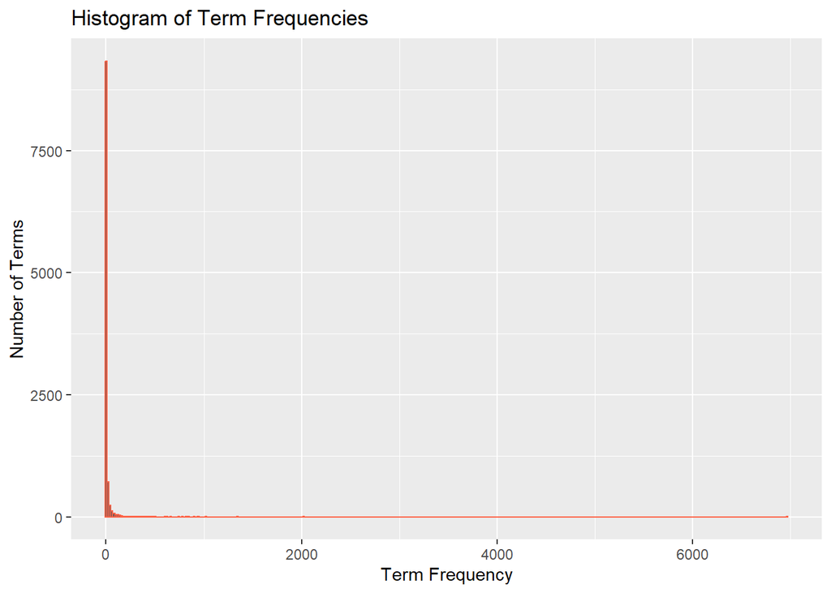

```r
# Create the histogram
ggplot(term_frequency_df, aes(x = frequency)) +
  geom_histogram(binwidth = 20,color='tomato1') +
  labs(title = "Histogram of Term Frequencies",
       x = "Term Frequency",
       y = "Number of Terms")+
  theme_gray()
```

Repeated and infrequent words was removed to prevent skewness of the topics. Terms that appear in more than 8% and less than 1% of the document were removed.

```r
# Words that appear in more than 8% of the document
frequent_terms <- findFreqTerms(tdm, lowfreq = 0.08 * ncol(tdm_matrix))


# Find terms that appear in less than 1% of documents
rare_terms <- findFreqTerms(tdm, highfreq = 0.01 * ncol(tdm_matrix))

print("Frequent Terms")
```

```
## [1] "Frequent Terms"
```

```r
print(frequent_terms)
```

```
##  [1] "also"       "author"     "book"       "easi"       "give"
##  [6] "good"       "great"      "help"       "inform"     "know"
## [11] "life"       "like"       "look"       "love"       "mani"
## [16] "much"       "need"       "read"       "recip"      "recommend"
## [21] "time"       "understand" "work"       "year"
```

```r
print("First 20 Infrequent Terms")
```

```
## [1] "First 20 Infrequent Terms"
```

```r
print(rare_terms[1:20])
```

```
##  [1] "aaaa"      "abandon"   "abbey"     "abbrevi"   "abdomen"   "abdomin"
##  [7] "abducte"   "abdul"     "abelar"    "abercleen" "aberdeen"  "abil"
## [13] "abiut"     "ablat"     "abli"      "abnorm"    "abnsolut"  "aboard"
## [19] "abomin"    "aborbt"
```

```r
# Keeping uselful words
to_keep <- c("love","recip")

to_remove <- frequent_terms[!frequent_terms %in% to_keep]

filtered_tdm_matrix <- tdm_matrix[!rownames(tdm_matrix) %in% to_remove, ]
filtered_tdm_matrix <- filtered_tdm_matrix[!rownames(filtered_tdm_matrix) %in% rare_terms, ]


# Calculate column sums
column_sums <- colSums(filtered_tdm_matrix)

# All zero columns
zero_columns <- which(column_sums == 0)

# Remove all zero columns or maintain original matrix
if(length(zero_columns) > 0) {
  filtered_tdm_matrix <- filtered_tdm_matrix[, -zero_columns]
} else {
  print("No zero columns in TDM matrix")
}
```

```r
term_frequencies <- rowSums(filtered_tdm_matrix)

#Create a data frame for plotting
term_frequency_df <- data.frame(term = names(term_frequencies), frequency = term_frequencies)

#Top 10 terms in descending order
top_terms <- term_frequency_df %>%
  arrange(desc(frequency)) %>%
  head(10)
print(top_terms)
```

```
##        term frequency
## love   love       931
## recip recip       848
## anyon anyon       407
## found found       401
## high   high       383
## think think       383
## find   find       373
## first first       371
## enjoy enjoy       370
## learn learn       366
```

Creating a histogram chart to display terms after the removal of irrelevant words.

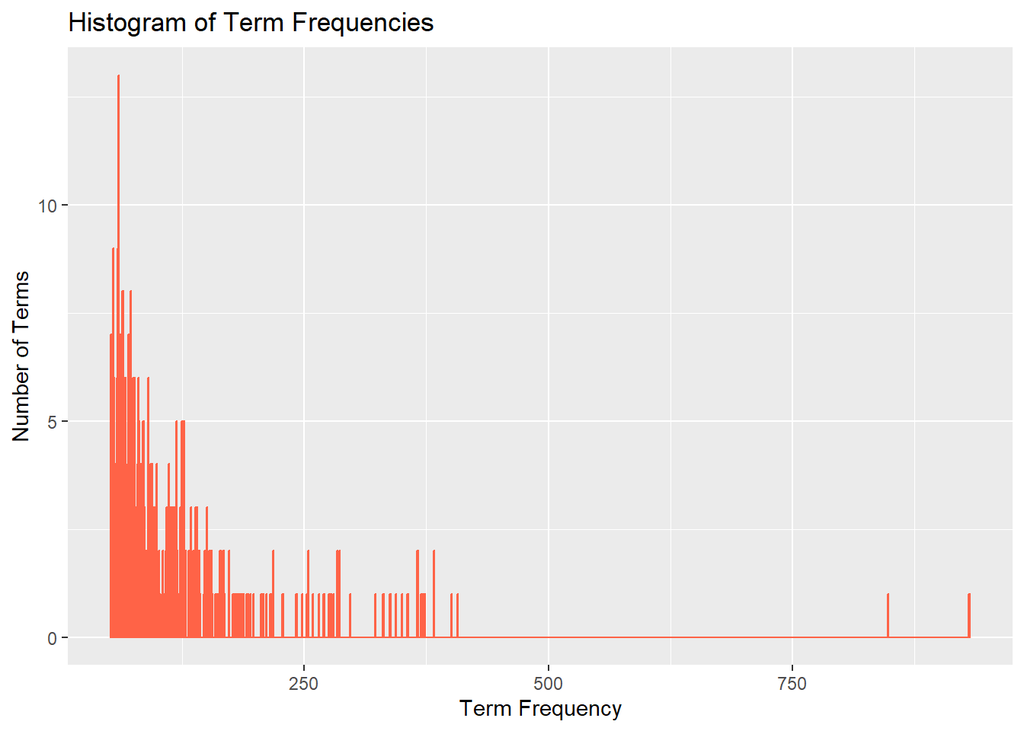

```r
# Create the histogram
ggplot(term_frequency_df, aes(x = frequency)) +
  geom_histogram(binwidth = 1,color='tomato1') +
  labs(title = "Histogram of Term Frequencies",
       x = "Term Frequency",
       y = "Number of Terms") +
  theme_gray()
```

```r
dtm <- t(filtered_tdm_matrix)
lda_model <- LDA(dtm, k = 6)
```

Visualizing topics created by the model

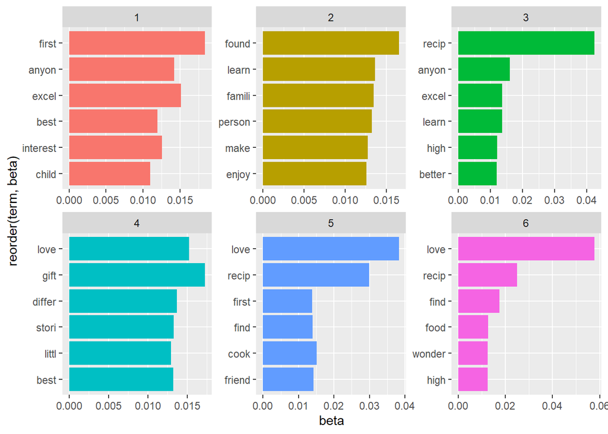

```r
#Creating a probability of each word in a topic
topics <- tidy(lda_model, matrix = "beta")

#Top 7 terms with highest probabliity
top_terms <- topics %>%
  group_by(topic) %>%
  top_n(6, beta) %>%
  ungroup() %>%
  arrange(topic, -beta)

#creating a bar chart with the terms in each topic
top_terms %>%
  ggplot(aes(x = reorder(term, beta),
             y = beta, fill = factor(topic))) +
  geom_col(show.legend = FALSE) +
  facet_wrap(~ topic, scales = "free") +
  coord_flip()
```

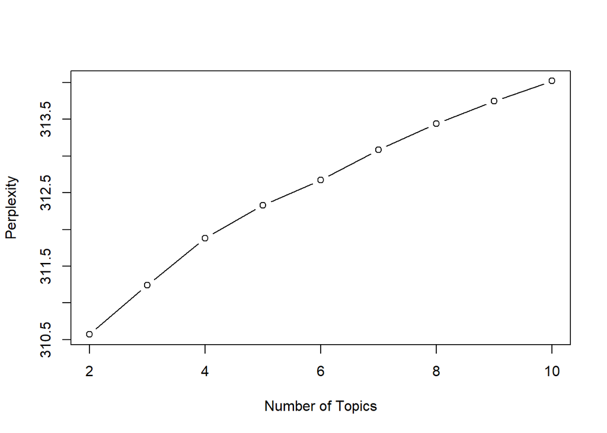

```r
range_k <- seq(2, 10, by = 1)
perplexities <- sapply(range_k, function(k) {
  model <- LDA(dtm, k = k, control = list(seed = 1))
  perplexity(model)
})

# Plotting perplexities
plot(range_k, perplexities, type = "b", xlab = "Number of Topics", ylab = "Perplexity")
```

This perplexity plot helps in the selection of the suitable number of topics for the model.

```r
set.seed(1)
lda_model <- LDA(dtm, k = 6)

lda_vis_data <- createJSON(phi = posterior(lda_model)$terms,
                          theta = posterior(lda_model)$topics,
                          doc.length = rowSums(as.matrix(dtm)),
                          vocab = colnames(as.matrix(dtm)),
                          term.frequency = colSums(as.matrix(dtm)))

serVis(lda_vis_data)
```

Second Topic: ‘Thinking, learning and connecting with people’ This will involve alot of self development,making new friends and connections.

Third 3: ‘Striving for excellence in cooking’ This might involve the act of trying to be good cook by cooking frequently and trying to get better at it each time.

Fourth Topic: ‘Love for health’ This topic will involve improving our health by making good social connections with people

Fifth Topic: ‘The Journey of Love: Exploring Connections, Joy, and Wonder’ It is a love that transcends boundaries of time and space, uniting kindred spirits in a shared journey of growth, discovery, and mutual support.

Sixth Topic: ‘Family Traditions and Treasured Memories: Recipes, Love, and Shared Stories’ This topic might be all about how to ensure family connections by probably cooking together

#NAIVE BAYES FOR PREDICTION selecting specific genres and limiting the number of observations, and creating a new variable to represent the classes based on the genre.

```r
#Selecting the genres to use for prediction and using only 50 observations
filtered_labels <-
  head(df1 %>% filter(Genre==c("Fiction","Religion")),50) %>% select(Title,Genre)

#Making Religion as class 0 and Fiction as class 1
data_with_class <-
  filtered_labels %>% mutate(class = ifelse(Genre=='Religion',0,1))
data_with_class
```

```
## # A tibble: 50 × 3
##    Title                                                             Genre class
##    <chr>                                                             <chr> <dbl>
##  1 The Secret of the Lord: The Simple Key that Will Revive Your Spi… Reli…     0
##  2 Hannibal                                                          Fict…     1
##  3 Angels and Women                                                  Fict…     1
##  4 The Collector's Edition of Victorian Lesbian Erotica              Fict…     1
##  5 The Man from Stone Creek                                          Fict…     1
##  6 Vox                                                               Fict…     1
##  7 Murder on the Rocks (Gray Whale Inn Mysteries, No. 1)             Fict…     1
##  8 Invisible Monsters: A Novel                                       Fict…     1
##  9 Bodega Dreams: A Novel                                            Fict…     1
## 10 The Woman Who Loved War                                           Fict…     1
## # ℹ 40 more rows
```

#creating a wordcloutplot

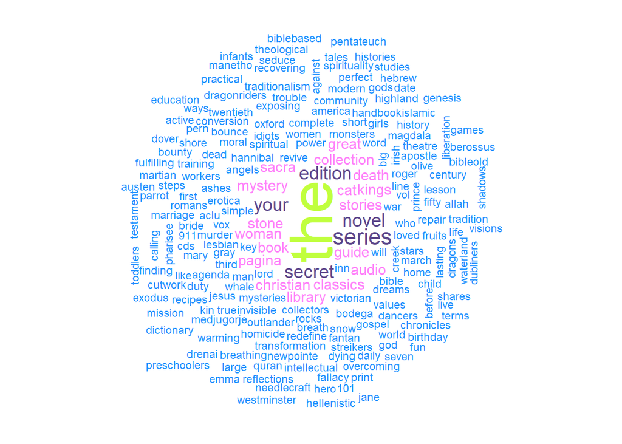

```r
wordcloud(words = data_with_class$Title, min.freq = 20, random.order=FALSE, random.color=FALSE, colors = sample(colors(), size = 10))
```

```r
#performing text classification.

# Sample text data
text_data <- data_with_class$Title

# Corresponding class labels
Genre <- data_with_class$class

# Convert text data to a data frame
data <- data.frame(text = text_data, Genre = Genre)

# Create a document-term matrix
corpus <- Corpus(VectorSource(data$text))
dtm <- DocumentTermMatrix(corpus)

# Convert to a matrix
dtm_matrix <- as.matrix(dtm)

# Perform text classification using Naive Bayes
nb_model <- naiveBayes(dtm_matrix, data$Genre)

# Sample test data
test_data <- "12 Steps for the Recovering Pharisee (like me)"

# Create a document-term matrix for test data
test_corpus <- Corpus(VectorSource(test_data))
test_dtm <- DocumentTermMatrix(test_corpus, control = list(dictionary = Terms(dtm)))

# Convert to a matrix
test_dtm_matrix <- as.matrix(test_dtm)

# Predict the class labels for test data
predictions <- predict(nb_model, test_dtm_matrix)

# Display the predictions
print("Predictions:")
```

```
## [1] "Predictions:"
```

```r
print(predictions)
```

```
## [1] 0
## Levels: 0 1
```